# [The Garden of Forking Paths](https://www.forkingpaths.co/)

# The False Gospel of Stuff and Status

We have become disciples of a flawed creed. To chase passion and value people is a much wiser way to live; or Ikigai, Detectorists, and the real meaning of life.

[Brian Klaas](https://substack.com/@brianklaas)

Feb 13, 2025

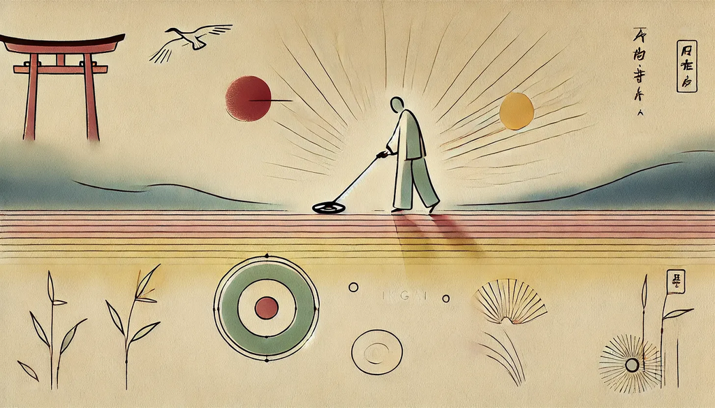

**Thank you for reading The Garden of Forking Paths. This edition is for everyone, but if you value my research and writing, please consider upgrading to a paid subscription—it costs only $4/month and fully unlocks 180+ essays. I rely exclusively on reader support. Or, consider buying my book [FLUKE](https://www.simonandschuster.com/books/Fluke/Brian-Klaas/9781668006535), named a “best book of 2024.”**

### I: The Fishermen

Have you heard the parable of the Mexican fishermen?

A banker from Manhattan jets down to Mexico one weekend for a package fishing holiday. He rents the best boat money can buy, removes his newly bought model of the world’s best fishing rod from its fresh packaging, attaches the latest high-tech lures, and begins to cast his line.

Impatiently waiting for his bobber to get tugged below the surface, he spots two smiling Mexican fishermen, aimlessly puttering along in a rickety old boat, laughing and chatting as their sturdy old rods poke above the rusted hull.

“You know,” the banker calls out to them, “instead of only going fishing, with just a tiny bit of investment capital, you guys could set up a lucrative tourist business. With the right commercial strategy and a decent website, you could make a killing down here.”

“And then what?” asks one of the Mexican fishermen.

“Well, and then you could buy another boat—a much fancier one!”

“And then what?”

“Well, and then you could franchise the operation. Hire some other fishermen, take a cut, start to really build a business empire! Everyone would envy you. You’d be the talk of the town. A big fish among the minnows!”

“And then what?” the fisherman presses.

“Well, and then you could take all your money and retire early! Imagine that!”

“And then what?”

“Well, and then you could just… *go fishing* *whenever you wanted*!”1

### II: Stuff, Status, and The Mirage of Faux Happiness

In the medieval town of San Gimignano, a 12th and 13th century status rivalry between aristocratic families transformed the skyline. In an escalating display of ever-greater riches and ratcheting power, money was converted into towers that soared far above the stone streets below. When a new tower eclipsed the previous tallest, it spurred a rush to build higher.

The overall height was of little importance; these towers were [not used for housing](https://extranet.sioe.org/uploads/isnie2011/vatiero.pdf). Instead, it was a battle of *relative* dominance. By the end of the medieval period, such social competition had transformed the town. There were an estimated 72 towers in place, a physical vestige of the endless showdown for status. The stonework formed an architectural homage to the infamous quip of J.S. Mill: “Men do not desire merely to be rich, but to be richer than other men.”

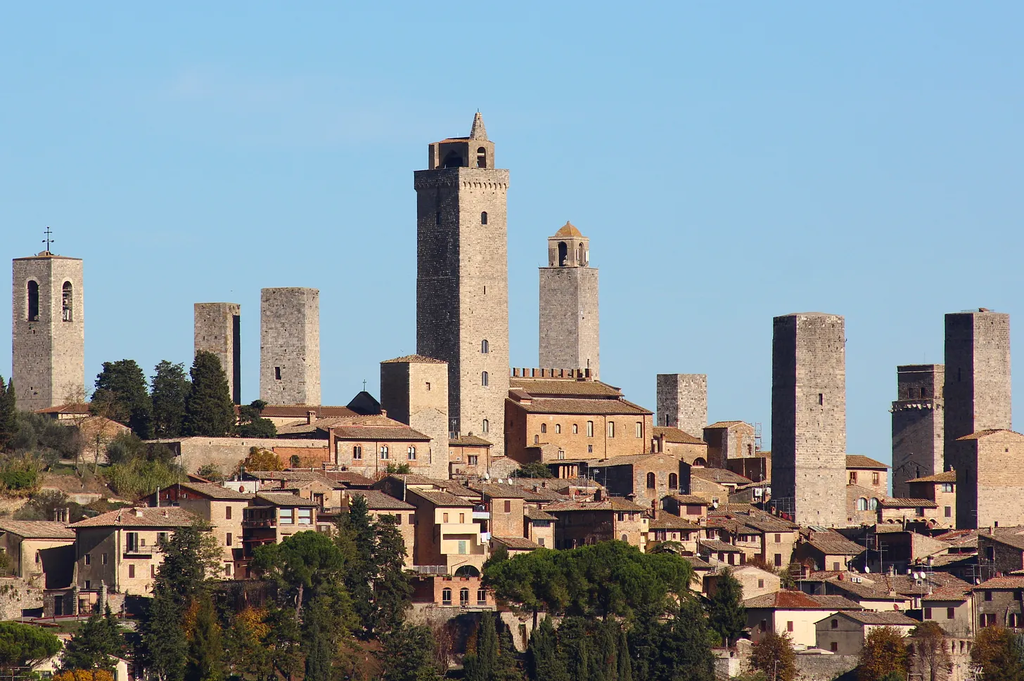

The towers of San Gimignano. Many original towers no longer exist.

Centuries later, our culture of Western modernity has bottled such visible competitive impulses and turned them into the dominant elixir of social life.

We have all been to *that* kind of party, where every question asked by *that* kind of person is a thinly disguised attempt to size up how lofty or lowly one is in the social pecking order. These questions of small talk are allergic to exploring ideas and passions; they are status-seeking probes, verbal metal detectors that triumphantly beep loudest when it is apparent that the asker is plainly “above” the answerer. Aha! *Their tower is lower*.

I, like hundreds of millions of others, grew up in the United States, arguably the most individualistic and success-oriented society to ever exist. It is a place that ostensibly runs, to a large extent, on the cultural creed of Christianity. But peer a bit closer and there is another belief system that explains far more of American culture than any other: the **Gospel of Stuff and Status**.2

Because of the enormous cultural power of the United States, this gospel converted legions of disciples well beyond its shores. At its extremes, its dogma offers Max Weber’s *protestant work ethic* on steroids, a cultural engine of toiling human machines that yields tremendous wealth, rapid innovation, and an endless sea of social despair. But its mantra is clear. As the German sociologist Hartmut Rosa [explains](https://www.politybooks.com/bookdetail?book_slug=resonance-a-sociology-of-our-relationship-to-the-world--9781509519897), “The categorial imperative of (late) modern decision-making is to *always act in such a way that your share of the world is increased*.”

Such increases can be in terms of *stuff*—the soulless physical accumulation of interchangeable objects that are mass produced in distant factories. Or, we can increase our relative share of the world with *status*, building our towers higher than our neighbors, enjoying a little bit more sunshine as we cast shadows over our less fortunate rivals.

However, just as a fish is unaware of water because they know nothing else, I was oblivious to the ways in which that cultural gospel was shaping my life until I left America—swimming in other social waters and exploring alternative ways of viewing the world. Yet, in modern life, it is easy to feel that we can never fully escape. We can only, for a time, become flying fish, glimpsing the other world that lies beyond reach, only to plunge back into the water from whence we came.

Our modern social world combines several unfortunate features, which, at their extremes, are reliable at producing social alienation and individual despair. What Weber called *disenchantment* arrived with the strict regimentation of the industrial age, in which the world was made to seem, as Rosa summarizes it “predictable, controllable, comprehensible, calculable, and thus accessible.” Spontaneity and community succumbed to the silent, atomized drudgery of assembly line lifestyles.

The philosophy of life that soon followed became one of domination, in which the world—both social and physical—was to be conquered by the individual. But that conquering mindset is incompatible with several facets of life that make us most delightfully human. The Scottish historian Thomas Carlyle, known best for his [Great Man theory of history](https://en.wikipedia.org/wiki/Great_man_theory), unapologetically endorsed toil for its own sake, not because work can produce passion, fulfilment, and joy: “Man was created to work, not to speculate, or feel, or dream…Every idle moment is treason.”3

Unsurprisingly, when that way of thinking leaks into modern culture, it manifests in bizarre ways, such as bragging about working seventy and eighty hour weeks while staring at a screen, as though such an existence is the badge of virtue and valor, rather than the dystopian reflection of a broken social system.

Rosa argues that this endless struggle is part of the *social acceleration* of the world, in which “we must run ever faster in order to maintain our place in the world.”4 This concept need not be explained at length; the overwhelming majority of people in modern professional life feel like they are struggling to *keep up*, as though daily life is an incessant treadmill that can never be switched off.

Because of the *competitive orientation* of capitalism and the imperative for *resource accumulation* (which can never be fully satisfied), Rosa suggests that we now automatically convert the awe-inspiring majesty of our world into a series of sterile, mute capital acquisitions. Economic capital allows us to grab more of the world; social capital allows us to access and exploit the prior accumulations of others; and if we fine-tune our bodies with the right supplements and icy plunge pools, our physical capital grows, allowing us to conquer ever more. It becomes, as the philosopher Theodor Adorno labeled it, a world of *bourgeois coldness*.

For many, that cold, endless race on the treadmill becomes tedious and tiresome, because we never get any closer to the destination—the ultimate goal of a fulfilling life. We lose sight of what Rosa calls *resonance*, joyful, passionate, moments where “[to-do lists are obliterated from our minds](https://www.forkingpaths.co/p/the-red-queen-fallacy) and we simply enjoy the ecstasy of a snapshot in our lives, whether it’s a euphoric interaction with other people, a sense of awe in the face of natural beauty, or the joy of acquiring fresh, outlook-altering knowledge.”

Instead, we end up following “a panicked logic that pushes all expectations of resonance off into the future. As long as we are occupied with completing tasks, working through our to-do lists, and meeting deadlines,” then we may feel justified in long stretches of distracting drudgery, hoping that doing will help us “obtain and secure the resources that will supposedly help us have a good life and experience resonance ‘later,’ when we have what we ‘actually’ want and are who we ‘really are.’”

This mentality provides the backdrop to modern tragedies, where millions feel unfulfilled day-to-day as they grind and slog for stuff and status, in the hope that their once-a-year holiday escape will make it all worthwhile. Then, their later search for resonance becomes an inauthentic commodity, yet another thing to toil to purchase. “*Buy yourself resonance!* is the implicit siren song of nearly all advertising campaigns and sale pitches,” Rosa explains. It leads to an escalating dynamic, where each trip needs to be bigger and better, each fresh object—the latest model of stuff—packed with better features, each escapist experience more exhilarating than the last. “*Resonance remains the promise of modernity, but alienation is its reality.*”

The gospel’s reach is so extensive that even in those moments in which we are trying to break free—to be deliberately mesmerized and awed by history or culture—we too often still succumb to its relentless pull.

Karen Armstrong [writes](https://www.penguin.co.uk/books/443025/sacred-nature-by-armstrong-karen/9781529114799) of her astute observation of shifts in modern museums, where teeming crowds now shuffle past humanity’s greatest relics not to contemplate them, but to digitally capture them. “They do not seem to want simply to commune with the Rosetta Stone,” she writes, “but to seek to own it in some way, as though it does not become real to them until they have a virtual copy.” Visiting the Mona Lisa is now a *terrible* experience precisely because it turns the visitor into a commodity on a cultural conveyer belt, queuing up to briefly snap a photo before scurrying off, having successfully “ticked the box.”

Even nature, a place that we now *go into* rather than consider ourselves *part of*, is often now measured in step counts, elevation achieved, number of peaks conquered. But, as I’ve [written previously](https://www.forkingpaths.co/p/against-optimization), “when everything becomes an instrumental goal to be optimized, intrinsic passion falls by the wayside, an infinite regress where each task and goal gives way to yet another—until you die.”

Thankfully, there is a better creed than the gospel of stuff and status—and it replaces those false idols with everlasting ones: *people* and *passion*.

### III: Extrinsic Motivation and Positional Arms Races

Human happiness, it is well understood, is far more resilient and lasting when it is derived from *intrinsic* rather than *extrinsic* (or external) motivation. In other words, we feel fulfilled when we are internally compelled to pursue goals that are exciting ends in themselves that *we value*, rather than always chasing a possible means to a future end that *someone else values*. Likewise, it is a more lasting form of fulfilment to experience a joyful, memorable moment that fulfils you personally than to get the fleeting dopamine hit of likes when you post about it on social media.

While hard work and dedication to a passion is made sweeter when it leads to a moment of triumph, Bertrand Russell warned us that too often the focus gets inverted, leading to unhappiness derived from “a quite undue emphasis upon the achievement as opposed to the activities connected with it.” No matter how great the payoff, if the daily journey is always a slog, it’s not going to make a happy life.

Similarly, there is nothing inherently problematic about wanting to acquire stuff. After all, even the most ascetic Bohemians ache for it. The musician cannot pursue his or her passion without a good instrument; the artist loves a perfectly crafted brush; intellectually curious thinkers and writers pour money away as their houses swell with books. Stuff becomes a problem when it becomes extrinsically motivated, when it’s about buying objects as social markers, rather than for intrinsic interest and passion.

Unfortunately, we—modern humans—are creatures of relative status who often use stuff as a tool to convey our social rank. The economist Fred Hirsch used the term *positional goods* to refer to such items or social assets that are valued precisely because they are scarce, finite, and socially desirable.

On one end of the spectrum are the least positional goods—paperclips, for example—where they are cheap, exist in near unlimited abundance, and convey nothing about social position. On the other extreme are priceless, singular works of art, valued not just for their beauty, but for the elite uniqueness that confers socially constructed value. This is why, for example, Saudi Arabia’s murderous crown prince, Mohammed Bin Salman, paid $450 million to [buy the famed](https://www.theatlantic.com/international/archive/2025/02/the-ultrarich-werent-always-this-selfish/681599/) *[Salvator Mundi](https://www.theatlantic.com/international/archive/2025/02/the-ultrarich-werent-always-this-selfish/681599/)* [painting before displaying it on his superyacht](https://www.theatlantic.com/international/archive/2025/02/the-ultrarich-werent-always-this-selfish/681599/).

But the most prized positional goods are abstract: status, power, rank in the social hierarchy. These are, by definition, finite. If everyone is a CEO, then nobody is. If everyone is rich, nobody is. Such metrics are based on *relative* rather than *absolute* accumulation, which makes them a zero-sum game. One’s gain is someone else’s loss.

The economist Robert Frank [illustrates](https://inequality.stanford.edu/sites/default/files/media/_media/pdf/Reference%20Media/Frank_2005_Consumption%20and%20Lifestyles.pdf) this with rival thought experiments. In the first, people are given a choice between living in a 4,000 square foot house, while everyone else around you lives in a 6,000 square foot house, *or* living in a 3,000 square foot house, while everyone else inhabits a 2,000 square foot house. Most people, it turns out, prefer the latter option, even though the absolute size of their house would be smaller.

By contrast, consider a world in which you get four weeks of vacation time while everyone else gets six, *or* where you get two weeks of vacation time and everyone else just gets one. In that scenario, people tend to choose the larger absolute amount of vacation time, regardless of what other people get. In other words, house size is a positional good, whereas vacation time is not.

Plenty of research confirms these strange dynamics, including a landmark economic study showing that people get [significantly less happy when their neighbors get comparatively richer](https://www.nber.org/system/files/working_papers/w10667/w10667.pdf). This is, quite obviously, silly and foolish to lash our prospects for our own happiness to the masts of our neighbors’ bank balances, but this dynamic defines an enormous chunk of modern social life. We end up in all-consuming positional arms races, often pointless battles for relative status. More confounding still, because the struggle for basic goods has effectively been eliminated from the lives of most people living in rich democracies, the role of positional goods has only increased over time.

Put differently, disconnecting work from its historic role of obtaining the basic necessities of life means that status becomes an even greater fixation. That’s why so many people—even those with what David Graeber called “bullshit jobs”—attach their personal sense of self-worth to climbing a hierarchy to the top of an organization that provides them with precisely zero intrinsic motivation. It’s a rat race to meaninglessness, but the wheel always beckons.

As Bertrand Russell put it: “what people fear when they engage in the struggle is not that they will fail to get their breakfast next morning, but that they will fail to outshine their neighbours.”

### IV: People, Passion, and the Search for Real Treasure

Well-crafted art can often expose the absurdity of life’s false idols in ways that are more visceral than intellectual analyses. And nowhere is the critique of the unfulfilling gospel of stuff and status more effectively and charmingly done than by the BBC sitcom *[Detectorists](https://www.youtube.com/watch?v=LU3myhsB-AQ)*, a genius, slow-burning show about what matters.5

On paper, by the sterile metrics of the False Gospel, the two main characters—Lance and Andy—have seemingly undesirable lives. Lance works at a warehouse facility, loading vegetables into shipments. Andy is well-educated, but relentlessly unemployed or under-employed, scrounging for work while living an economically precarious life, dependent on his partner, Becky, who is a schoolteacher. At first glance, they are, in the words of [Phil Wickham](https://www.manchesterhive.com/display/9781526170231/9781526170231.00011.xml), “classic small-town underachievers representing the least attractive traits of middle-aged men.”

But unlike most people, they do not introduce or define themselves by their jobs. They are introduced as *detectorists*. Their hobby for metal detecting—always in a seemingly hopeless quest to find historical treasure that connects their lives to a larger past—is an all-consuming passion. As they go through life, sweeping their occasionally beeping devices across ancient fields, they experience “the ordinary” as “[the epic](https://www.manchesterhive.com/display/9781526170231/9781526170231.00011.xml),” finding intensely fulfilling meaning through the daily joy of doing something they deeply love. Even when Andy is employed, often as a janitor, his movements of the vacuum cleaner or the mop mimic the sweep of the detector.

The villains of the series are the “nighthawks,” unscrupulous gold hunters who see metal detecting solely as a means to riches, rather than an intrinsically valuable pursuit. Chasing hidden monetary value distracts them from the more fulfilling experience of the activity itself—and the connection it forges between past and present within nature. They lose sight of the essence of pure detecting: making one feel a visceral sense of being part of the historic sweep of humanity.

In one poignant scene, as [Hannah Andrews and Gregory Frame point out](https://www.taylorfrancis.com/chapters/edit/10.4324/9781032699622-3/quiet-quitters-hannah-andrews-gregory-frame), Lance finally does discover an ancient gold coin, but pauses to photograph it in place, ensuring that they record its resting place for the historical record. In that pause, a magpie swoops in and snatches the coin, representing the mistaken belief that shiny objects are all that matter.

Throughout the show, the allure of money and valuable treasure lurks, but whenever it seduces the detectorists and they lose sight of their intrinsic motivation, their lives begin to fall apart, cursed by a momentarily conversion to the False Gospel. In the end, Lance concludes that he’d rather not step foot onto the relentless social treadmill. “On TV, all these people reaching for the stars, striving to be the best. It’s exhausting.” His soothing vision of a modest life well-lived is jarringly different from aspirational fantasies typically produced on television.

Despite their real struggles, the show reveals Lance and Andy to have extraordinarily enviable rich lives that are completely separate from their bank accounts or their status in society. They wake up every morning with passion, spend their days fulfilled, and develop deep, meaningful friendships over pints at the pub after their latest detecting gambit has failed to produce the expected treasure.

But as Wickham underlines, their lives are enriched precisely because “the detectorists know that it is not the gold that is important so much as the process of discovery.” Free from the rat race, they find real, lasting happiness and enduring life satisfaction by worshipping better idols: people and passion.

Unfortunately, modern society seems to be drifting further and further from this *Detectorists* model of the passionate, people-oriented meaning of life. Recent data suggest that the trends identified in *[Bowling Alone](https://en.wikipedia.org/wiki/Bowling_Alone)*—of social atomization and loneliness—are only getting worse. From 2003 to 2023, in-person socializing [declined by more than 20 percent](https://www.theatlantic.com/magazine/archive/2025/02/american-loneliness-personality-politics/681091/).

It’s not just a pandemic trend, either. As highlighted recently in *[The Atlantic](https://www.theatlantic.com/magazine/archive/2025/02/american-loneliness-personality-politics/681091/)*, “according to Enghin Atalay, an economist at the Federal Reserve Bank of Philadelphia, [Americans spent even more time alone in 2023](https://www.philadelphiafed.org/-/media/frbp/assets/working-papers/2022/wp22-11.pdf) than they did in 2021.” This comes as leisure time increased, but much of that extra time, the data show, did not get diverted to self-directed passions, but to watching TV and scrolling social media. One can certainly enjoy amusing videos, but few would describe those moments as the enduring, life-enhancing experiences of resonance. It can yield an isolated, lonely existence, what Hartmut Rosa describes as a “relation of relationlessness,” a lack of real connection with the world.

### V: How You Live Your Days is How You Live Your Life

You only live 30,000 days.6 Put that way, it’s harder to ignore an obvious truth: that how you live your days is how you live your life.

That lesson is the central message of the Oscar-nominated film *Perfect Days*, which, like *Detectorists*, finds a role model for how to live in the unlikeliest of places. In this case, the life we see is that of a man named Hirayama, who inhabits a somewhat Sisyphean existence while cleaning public toilets in Tokyo.

But rather than let this undesirable profession repulse him, he revels in life, taking pride in his work, finding meaning in unexpected places, and contemplating *komorebi*—the dappled light of the sun, filtered through a beautiful canopy of leaves—while on his lunch breaks.7 Instead of fixating on his next holiday or trying to find ways to distract himself to escape from his life, he learns to savor the dazzling moments of his existence, even within the seemingly mundane.

“Next time is next time, now is now,” he says, while enjoying a bike ride with his more future-oriented niece. The stuff that gives Hirayama joy consists of a few treasured objects. There is no consideration of social status. He doesn’t need external validation to be happy and fulfilled. Human emotions such as awe, appreciation for the small joys of life, and a sense of pride in what one does in the finite time we have on Earth are *not* positional goods. They are intrinsically valuable—and are not zero sum games. One person’s greater sense of awe does not lead to someone else’s loss of it.

Set in Tokyo, the film echoes a frequently discussed idea in Japanese culture: *ikigai*, or having a life purpose. A significant body of research has shown that people who express a clear sense of intrinsic purpose—not having more stuff or status than those around them—[live longer, healthier lives](https://se-realiser.com/wp-content/uploads/2018/11/Sone-et-al.-Ikigai-and-Mortality-in-Japan-2008.pdf). The False Gospel stresses us out; a more humane belief structure can save us.

There is no escape from every aspect of modernity’s faux creed. We are creatures socially defined by status who live in a world geared toward making us want more stuff. But awareness of false idols can help liberate us from their worst harms. Like the detectorists, savoring the intrinsic quest rather than the extrinsic treasure is a wise antidote to modern social alienation.

After all, we are all transient flukes, agglomerations of networked atoms, infused, for a time, with consciousness. The value of our lives lies not with building ever higher towers to impress others, but ensuring that our bundle of atoms is fulfilled with passion, while enjoying, enriching, and improving the lives of others who happen to have blinked into existence at the same time as us, sharing this weird and wonderful planet.

**Thank you for reading The Garden of Forking Paths. This essay was for everyone, but as you might have surmised while reading it, these essays take quite a while to research and write. If you value my work and want me to keep writing for you, please consider paying for a subscription—and fully unlocking the archive of 180+ other essays for just $4/month.**

1

This popularized parable is likely derived from Anekdote zur Senkung der Arbeitsmoral (“Anecdote on lowering the work ethic”) by Heinrich Boll, which is probably inspired by the anecdote of Pyrrhus and Cineas in Plutarch. I’ve modestly altered it for the purposes of this essay.

2

It is appropriate that the surging forms of religion in an atomized modern America are tied to the “prosperity gospel,” in which God delivers wealth on command.

3

Sounds like he’d be fun at parties.

4

I wrote about this idea in an essay called “[The Red Queen Fallacy](https://www.forkingpaths.co/p/the-red-queen-fallacy).”

5

The Detectorists [theme song](https://www.youtube.com/watch?v=Q58Gm18-IMY), by Johnny Flynn, is one of my favorite tracks of all-time. And the show is my favorite TV show I’ve watched in the last five years.

6

This line, which is my adventure-chasing uncle’s informal motto and occupies his e-mail signature, refers to an 82 year lifespan, which is slightly above current US life expectancy but is right on target for, say, the UK/Canada.

7

There is one fair critique of *Perfect Days*, in my view, that it overly glorifies the toilet cleaner’s life in a way that ends up valorizing systems that force people to toil in demeaning conditions. Sure, that’s true, but I think the larger message—of snatching joy from apparent meaninglessness—is far more powerful.

Wandering around an infinitely complex, ever changing world.

24

41

Share

[17h](https://www.forkingpaths.co/p/the-false-gospel-of-stuff-and-status/comment/93220495)Edited

Perhaps status and power is only another form of expression of the human desire to connect to the past and present (and future) of humanity, as our societies are structured around immortalising the important and the powerful.

When I was visiting Japan in spring a few years ago, I overheard an American woman ask the tour guide as we walked through the sea of cherry blossoms - “Who was the man responsible for planting all the cherry trees?” I thought it was such a great sum of American cultural mentality - always a single man responsible for something great and marvellous. She was not very satisfied when the guide responded that there was no such man, it was a tradition that evolved over generations.

Thanks for sharing, Brian. Made me close a few online shopping browser windows, full disclosure.

Reply

Share

[John](https://substack.com/profile/99623898-john?utm_source=substack-feed-item)

[Homer nods](https://f6q2133qs.substack.com/?utm_content=comment_metadata&utm_source=substack-feed-item)

[21h](https://www.forkingpaths.co/p/the-false-gospel-of-stuff-and-status/comment/93168123)

Detectorists is a fine show. Nice essay. Thanks Brian.

Reply

Share

Nov 30, 2022 •

[Brian Klaas](https://substack.com/@brianklaas)

1,127

7

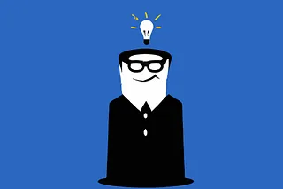

[He's back. Here's my advice on how to best cope with—and fight back against—the return of Donald Trump.](https://www.forkingpaths.co/p/how-to-survive-the-second-trump-era)

Jan 20 •

[Brian Klaas](https://substack.com/@brianklaas)

276

55

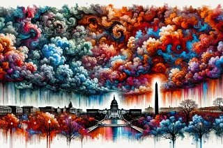

[What we can learn about intelligence, stupidity, and ourselves—from some of the smartest, strangest, alien-like creatures on the planet.](https://www.forkingpaths.co/p/the-evolution-of-stupidity-and-octopus)

Apr 23, 2024 •

[Brian Klaas](https://substack.com/@brianklaas)

707

26

[figure not shown]

Ready for more?

© 2025 Brian Klaas